### Title: “Breast Cancer Data Analysis, Cleaning, Modeling & Prediction”

## STEP 0 - REQUIRED LIBRARIES

## Install Libraries that we may need during workflow

```r
#install.packages(c("tidyverse","randomForest", "e1071",
                  # "class", "rpart", "rpart.plot", "pROC"))

#install.packages(c("recipes", "ggplot2", "lattice", "Matrix"))
```

## Load libraries

```r
#install.packages("corrplot")
library(corrplot)
library(tidyverse)
library(randomForest)
library(e1071)
library(class)
library(rpart)
library(rpart.plot)
library(pROC)
```

# STEP 1 - LOAD THE DATA

```r
# ADJUST the path to your own
data <- read.csv("C:/Users/Ana/Downloads/data.csv", stringsAsFactors = TRUE)
```

## View structure

```r
str(data)
```

```
## 'data.frame':    569 obs. of  33 variables:
##  $ id                     : int  842302 842517 84300903 84348301 84358402 843786 844359 84458202 844981 84501001 ...
##  $ diagnosis              : Factor w/ 2 levels "B","M": 2 2 2 2 2 2 2 2 2 2 ...
##  $ radius_mean            : num  18 20.6 19.7 11.4 20.3 ...
##  $ texture_mean           : num  10.4 17.8 21.2 20.4 14.3 ...
##  $ perimeter_mean         : num  122.8 132.9 130 77.6 135.1 ...
##  $ area_mean              : num  1001 1326 1203 386 1297 ...
##  $ smoothness_mean        : num  0.1184 0.0847 0.1096 0.1425 0.1003 ...
##  $ compactness_mean       : num  0.2776 0.0786 0.1599 0.2839 0.1328 ...
##  $ concavity_mean         : num  0.3001 0.0869 0.1974 0.2414 0.198 ...
##  $ concave.points_mean    : num  0.1471 0.0702 0.1279 0.1052 0.1043 ...
##  $ symmetry_mean          : num  0.242 0.181 0.207 0.26 0.181 ...
##  $ fractal_dimension_mean : num  0.0787 0.0567 0.06 0.0974 0.0588 ...
##  $ radius_se              : num  1.095 0.543 0.746 0.496 0.757 ...
##  $ texture_se             : num  0.905 0.734 0.787 1.156 0.781 ...
```

[output cut: 19 more lines]

## First few rows

```r
head(data)
```

```
##         id diagnosis radius_mean texture_mean perimeter_mean area_mean
## 1   842302         M       17.99        10.38         122.80    1001.0
## 2   842517         M       20.57        17.77         132.90    1326.0
## 3 84300903         M       19.69        21.25         130.00    1203.0
## 4 84348301         M       11.42        20.38          77.58     386.1
## 5 84358402         M       20.29        14.34         135.10    1297.0
## 6   843786         M       12.45        15.70          82.57     477.1
##   smoothness_mean compactness_mean concavity_mean concave.points_mean
## 1         0.11840          0.27760         0.3001             0.14710
## 2         0.08474          0.07864         0.0869             0.07017
## 3         0.10960          0.15990         0.1974             0.12790
## 4         0.14250          0.28390         0.2414             0.10520
## 5         0.10030          0.13280         0.1980             0.10430
## 6         0.12780          0.17000         0.1578             0.08089
##   symmetry_mean fractal_dimension_mean radius_se texture_se perimeter_se
```

[output cut: 34 more lines]

## Ensure target variable is factor

```r
data$diagnosis <- as.factor(data$diagnosis)
```

# STEP 2 — QUICK DATA CHECK

```r
# Class distribution

table(data$diagnosis)
```

```
##
##   B   M
## 357 212
```

```r
# No missing values expected

sum(is.na(data))
```

```
## [1] 569
```

```r
colSums(is.na(data))
```

```
##                      id               diagnosis             radius_mean
##                       0                       0                       0
##            texture_mean          perimeter_mean               area_mean
##                       0                       0                       0
##         smoothness_mean        compactness_mean          concavity_mean
##                       0                       0                       0
##     concave.points_mean           symmetry_mean  fractal_dimension_mean
##                       0                       0                       0
##               radius_se              texture_se            perimeter_se
##                       0                       0                       0
##                 area_se           smoothness_se          compactness_se
##                       0                       0                       0
##            concavity_se       concave.points_se             symmetry_se
##                       0                       0                       0
##    fractal_dimension_se            radius_worst           texture_worst
##                       0                       0                       0
##         perimeter_worst              area_worst        smoothness_worst
##                       0                       0                       0
##       compactness_worst         concavity_worst    concave.points_worst
##                       0                       0                       0
##          symmetry_worst fractal_dimension_worst                       X
##                       0                       0                     569
```

# STEP 3 — DATA CLEANING

-Let’s just recheck the names of the columns and see if it is anything suspicious!

```r
colnames(data)
```

```
##  [1] "id"                      "diagnosis"
##  [3] "radius_mean"             "texture_mean"
##  [5] "perimeter_mean"          "area_mean"
##  [7] "smoothness_mean"         "compactness_mean"
##  [9] "concavity_mean"          "concave.points_mean"
## [11] "symmetry_mean"           "fractal_dimension_mean"
## [13] "radius_se"               "texture_se"
## [15] "perimeter_se"            "area_se"
## [17] "smoothness_se"           "compactness_se"
## [19] "concavity_se"            "concave.points_se"
## [21] "symmetry_se"             "fractal_dimension_se"
## [23] "radius_worst"            "texture_worst"
## [25] "perimeter_worst"         "area_worst"
## [27] "smoothness_worst"        "compactness_worst"
## [29] "concavity_worst"         "concave.points_worst"
## [31] "symmetry_worst"          "fractal_dimension_worst"
## [33] "X"
```

```r
summary(data$X)
```

```
##    Mode    NA's
## logical     569
```

```r
data <- data[, colnames(data) != "X"]
```

```r
# Drop ID, because we do not need it!

if ("id" %in% names(data)) {
data <- data %>% select(-id)
}
```

```r
# Ensure target is factor

data$diagnosis <- as.factor(data$diagnosis)

summary(data$diagnosis)
```

```
##   B   M
## 357 212
```

So here we realise the number of each category of the type of breast cancer.

# STEP 4 — EXPLORATORY DATA ANALYSIS (EDA)

## Summary statistics

```r
summary(data)
```

```
##  diagnosis  radius_mean      texture_mean   perimeter_mean     area_mean
##  B:357     Min.   : 6.981   Min.   : 9.71   Min.   : 43.79   Min.   : 143.5
##  M:212     1st Qu.:11.700   1st Qu.:16.17   1st Qu.: 75.17   1st Qu.: 420.3
##            Median :13.370   Median :18.84   Median : 86.24   Median : 551.1
##            Mean   :14.127   Mean   :19.29   Mean   : 91.97   Mean   : 654.9
##            3rd Qu.:15.780   3rd Qu.:21.80   3rd Qu.:104.10   3rd Qu.: 782.7
##            Max.   :28.110   Max.   :39.28   Max.   :188.50   Max.   :2501.0
##  smoothness_mean   compactness_mean  concavity_mean    concave.points_mean
##  Min.   :0.05263   Min.   :0.01938   Min.   :0.00000   Min.   :0.00000
##  1st Qu.:0.08637   1st Qu.:0.06492   1st Qu.:0.02956   1st Qu.:0.02031
##  Median :0.09587   Median :0.09263   Median :0.06154   Median :0.03350
##  Mean   :0.09636   Mean   :0.10434   Mean   :0.08880   Mean   :0.04892
##  3rd Qu.:0.10530   3rd Qu.:0.13040   3rd Qu.:0.13070   3rd Qu.:0.07400
##  Max.   :0.16340   Max.   :0.34540   Max.   :0.42680   Max.   :0.20120
##  symmetry_mean    fractal_dimension_mean   radius_se        texture_se
##  Min.   :0.1060   Min.   :0.04996        Min.   :0.1115   Min.   :0.3602
##  1st Qu.:0.1619   1st Qu.:0.05770        1st Qu.:0.2324   1st Qu.:0.8339
##  Median :0.1792   Median :0.06154        Median :0.3242   Median :1.1080
##  Mean   :0.1812   Mean   :0.06280        Mean   :0.4052   Mean   :1.2169
##  3rd Qu.:0.1957   3rd Qu.:0.06612        3rd Qu.:0.4789   3rd Qu.:1.4740
##  Max.   :0.3040   Max.   :0.09744        Max.   :2.8730   Max.   :4.8850
##   perimeter_se       area_se        smoothness_se      compactness_se
##  Min.   : 0.757   Min.   :  6.802   Min.   :0.001713   Min.   :0.002252
##  1st Qu.: 1.606   1st Qu.: 17.850   1st Qu.:0.005169   1st Qu.:0.013080
##  Median : 2.287   Median : 24.530   Median :0.006380   Median :0.020450
##  Mean   : 2.866   Mean   : 40.337   Mean   :0.007041   Mean   :0.025478
##  3rd Qu.: 3.357   3rd Qu.: 45.190   3rd Qu.:0.008146   3rd Qu.:0.032450
##  Max.   :21.980   Max.   :542.200   Max.   :0.031130   Max.   :0.135400
##   concavity_se     concave.points_se   symmetry_se       fractal_dimension_se
##  Min.   :0.00000   Min.   :0.000000   Min.   :0.007882   Min.   :0.0008948
##  1st Qu.:0.01509   1st Qu.:0.007638   1st Qu.:0.015160   1st Qu.:0.0022480
##  Median :0.02589   Median :0.010930   Median :0.018730   Median :0.0031870
##  Mean   :0.03189   Mean   :0.011796   Mean   :0.020542   Mean   :0.0037949
##  3rd Qu.:0.04205   3rd Qu.:0.014710   3rd Qu.:0.023480   3rd Qu.:0.0045580
##  Max.   :0.39600   Max.   :0.052790   Max.   :0.078950   Max.   :0.0298400
##   radius_worst   texture_worst   perimeter_worst    area_worst
##  Min.   : 7.93   Min.   :12.02   Min.   : 50.41   Min.   : 185.2
##  1st Qu.:13.01   1st Qu.:21.08   1st Qu.: 84.11   1st Qu.: 515.3
##  Median :14.97   Median :25.41   Median : 97.66   Median : 686.5
##  Mean   :16.27   Mean   :25.68   Mean   :107.26   Mean   : 880.6
##  3rd Qu.:18.79   3rd Qu.:29.72   3rd Qu.:125.40   3rd Qu.:1084.0
##  Max.   :36.04   Max.   :49.54   Max.   :251.20   Max.   :4254.0
##  smoothness_worst  compactness_worst concavity_worst  concave.points_worst
##  Min.   :0.07117   Min.   :0.02729   Min.   :0.0000   Min.   :0.00000
##  1st Qu.:0.11660   1st Qu.:0.14720   1st Qu.:0.1145   1st Qu.:0.06493
##  Median :0.13130   Median :0.21190   Median :0.2267   Median :0.09993
##  Mean   :0.13237   Mean   :0.25427   Mean   :0.2722   Mean   :0.11461
##  3rd Qu.:0.14600   3rd Qu.:0.33910   3rd Qu.:0.3829   3rd Qu.:0.16140
##  Max.   :0.22260   Max.   :1.05800   Max.   :1.2520   Max.   :0.29100
##  symmetry_worst   fractal_dimension_worst
##  Min.   :0.1565   Min.   :0.05504
##  1st Qu.:0.2504   1st Qu.:0.07146
##  Median :0.2822   Median :0.08004
##  Mean   :0.2901   Mean   :0.08395
##  3rd Qu.:0.3179   3rd Qu.:0.09208
##  Max.   :0.6638   Max.   :0.20750
```

## Correlation Matrix will help us define the relations between our variables.

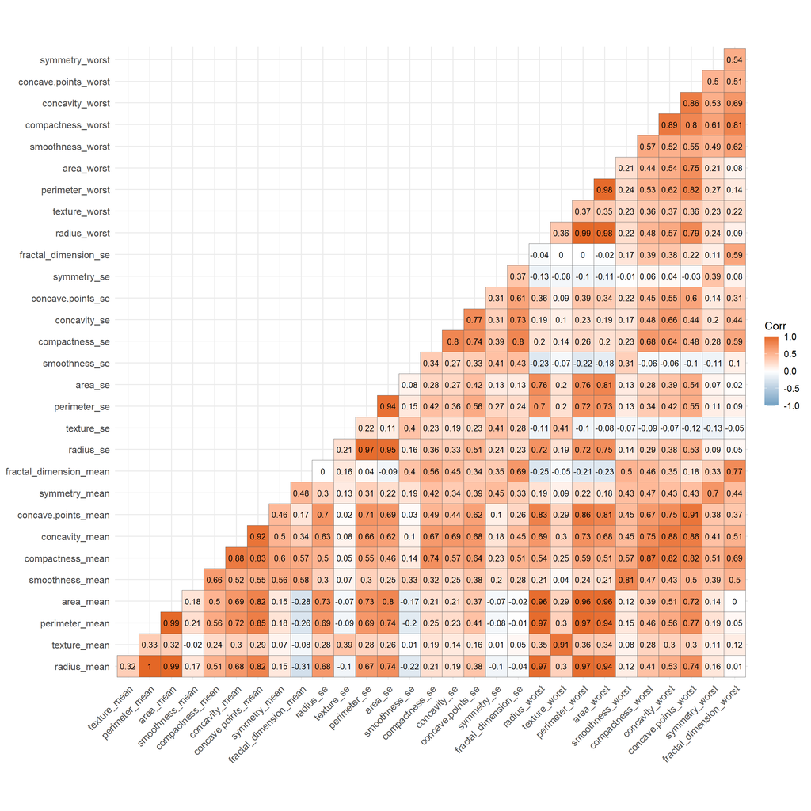

```r
#install.packages("ggcorrplot")
library(ggcorrplot)
cor_matrix <- cor(data %>% select(-diagnosis))

ggcorrplot(
  cor_matrix,
  method = "square",
  type = "lower",
  lab = TRUE,
  lab_size = 3.5,                    # bigger numbers
  colors = c("#6D9EC1", "white", "#E46726"),
  outline.color = "grey40",
  tl.cex = 12,                       # bigger axis labels
  tl.srt = 45,                       # rotate axis labels
  tl.col = "black",
  ggtheme = ggplot2::theme_minimal(base_size = 14)
)
```

## Interpretation of the Correlation Matrix

1. Size-Related Features — Extremely Strong Positive Correlation (0.95–0.99)

Variables: radius_mean, perimeter_mean, area_mean and their _worst versions.

These features measure tumor size, which is geometrically linked (larger radius → larger perimeter → larger area). ➡ We can treat these variables as redundant and keep only one representative from this size cluster.

2. Shape Irregularity Features — Strong Positive Correlation (0.80–0.90)

Variables: concave.points_mean, concavity_mean, compactness_mean, and their _se and _worst versions.

These quantify tumor border irregularity. ➡ They carry overlapping information, so we should keep only one key variable from this shape-related cluster.

3. Mean vs. Worst Correlations — Very High Overlap

Examples:

radius_mean ↔︎ radius_worst ≈ 0.97

Worst values essentially mirror the mean values. ➡ We likely do not need both mean and worst versions of each measurement.

4. Weak or Negative Correlations — Independent Features

Variables with weak/negative correlations:

smoothness_se (small negatives)

These do not follow size or shape patterns. ➡ They provide independent signal and are useful to keep for prediction.

5. SE Variables (Standard Errors) — Moderate Correlations (0.2–0.7)

SE variables describe variability rather than size or shape. ➡ They sit between clusters and add intermediate information.

## Feature distributions

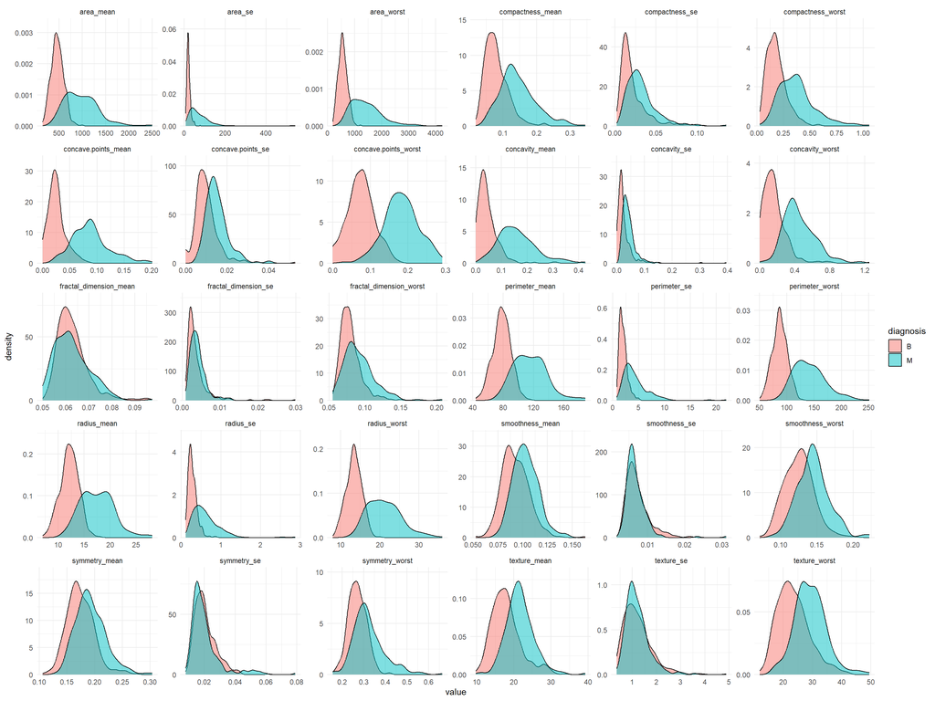

```r
data %>%
  gather(feature, value, -diagnosis) %>%
  ggplot(aes(x = value, fill = diagnosis)) +
  geom_density(alpha = 0.5) +
  facet_wrap(~feature, scales = "free") +
  scale_y_continuous(
    breaks = scales::pretty_breaks(n = 3),
    expand = expansion(mult = c(0, 0.15))
  ) +
  theme_minimal() +
  theme(
    axis.text.y  = element_text(size = 9),
    axis.title.y = element_text(size = 11)
  )
```

## Interpretation of the Density Plots

Clear class separation is visible for size-related features (area, radius, perimeter), especially their _worst and _mean versions. Malignant tumors tend to have higher values and right-shifted distributions compared to benign ones.

Shape irregularity features (concavity, concave points, compactness) also show strong discrimination, with malignant cases exhibiting larger and more variable values.

Texture, smoothness, symmetry, and fractal dimension show greater overlap between classes, indicating weaker individual discriminative power.

SE (standard error) features are highly skewed and overlap substantially, suggesting they contribute less on their own.

## Conclusion

Tumor size and border irregularity are the most informative features for distinguishing malignant from benign cases, while texture- and variability-based features provide secondary, complementary information.

# STEP 5 — TRAIN / TEST SPLIT

```r
set.seed(123)

# 80% training indices
trainIndex <- sample(seq_len(nrow(data)), size = 0.8 * nrow(data))

# Create training and testing sets
trainData <- data[trainIndex, ]
testData  <- data[-trainIndex, ]
```

# STEP 6 — FEATURE SCALING

```r
# Select only numeric predictors
train_numeric <- trainData %>% select(-diagnosis)
test_numeric  <- testData %>% select(-diagnosis)

# Compute mean and sd from training data
train_means <- apply(train_numeric, 2, mean)
train_sds   <- apply(train_numeric, 2, sd)

# Scale training data
trainScaled <- as.data.frame(scale(train_numeric,
                                   center = train_means,
                                   scale = train_sds))

# Scale testing data using TRAIN statistics
testScaled <- as.data.frame(scale(test_numeric,
                                  center = train_means,
                                  scale = train_sds))

# Add diagnosis back
trainScaled$diagnosis <- trainData$diagnosis
testScaled$diagnosis  <- testData$diagnosis
```

# STEP 7 — MODELING

## A) Logistic Regression

```r
# A) Logistic Regression

log_model <- glm(diagnosis ~ ., data = trainScaled, family = binomial)
# Predicted probabilities
pred_prob_log <- predict(log_model, newdata = testScaled, type = "response")

# Convert to class labels
pred_class_log <- ifelse(pred_prob_log > 0.5, "M", "B")

# Convert predicted + actual to factors with same levels
pred_class_log <- factor(pred_class_log, levels = c("B", "M"))
actual_class   <- factor(testScaled$diagnosis, levels = c("B", "M"))

# Confusion matrix (caret replacement)
conf_matrix_log <- table(Predicted = pred_class_log,
                         Actual = actual_class)

conf_matrix_log
```

```
##          Actual
## Predicted  B  M
##         B 57  0
##         M  4 53
```

Only 4 benign samples were misclassified as malignant — small error.

## Metrics to measure the performance of the model

```r
TP <- conf_matrix_log["M","M"]
TN <- conf_matrix_log["B","B"]
FP <- conf_matrix_log["M","B"]
FN <- conf_matrix_log["B","M"]

accuracy  <- (TP + TN) / sum(conf_matrix_log)
sensitivity <- TP / (TP + FN)
specificity <- TN / (TN + FP)
precision <- TP / (TP + FP)
f1_score <- 2 * (precision * sensitivity) / (precision + sensitivity)

list(
  Accuracy = accuracy,
  Sensitivity = sensitivity,
  Specificity = specificity,
  Precision = precision,
  F1_Score = f1_score
)
```

```
## $Accuracy
## [1] 0.9649123
##
## $Sensitivity
## [1] 1
##
## $Specificity
## [1] 0.9344262
##
## $Precision
## [1] 0.9298246
##
## $F1_Score
## [1] 0.9636364
```

Accuracy is very high: (57 + 53) / (57 + 0 + 4 + 53) = 110 / 114 ≈ 0.965 → 96.5%

Sensitivity (Recall for M): TP / (TP + FN) = 53 / (53 + 0) = 1.0 → perfect recall for malignant

Specificity (Recall for B): TN / (TN + FP) = 57 / (57 + 4) ≈ 0.934 → very good

## B) KNN (k = 7)

```r
library(class)  # for knn

# Set k
k <- 7

# KNN predictions
knn_pred <- knn(
  train = trainScaled[, -ncol(trainScaled)],
  test  = testScaled[, -ncol(testScaled)],
  cl    = trainScaled$diagnosis,
  k     = k
)

# Convert to factors with same levels
knn_pred <- factor(knn_pred, levels = c("B", "M"))
actual_class <- factor(testScaled$diagnosis, levels = c("B", "M"))

# Confusion matrix
conf_matrix_knn <- table(Predicted = knn_pred, Actual = actual_class)
conf_matrix_knn
```

```
##          Actual
## Predicted  B  M
##         B 60  5
##         M  1 48
```

```r
TP <- conf_matrix_knn["M","M"]
TN <- conf_matrix_knn["B","B"]
FP <- conf_matrix_knn["M","B"]
FN <- conf_matrix_knn["B","M"]

accuracy  <- (TP + TN) / sum(conf_matrix_knn)
sensitivity <- TP / (TP + FN)      # Recall for M
specificity <- TN / (TN + FP)      # Recall for B
precision   <- TP / (TP + FP)
f1_score    <- 2 * (precision * sensitivity) / (precision + sensitivity)

list(
  Confusion_Matrix = conf_matrix_knn,
  Accuracy = accuracy,
  Sensitivity = sensitivity,
  Specificity = specificity,
  Precision = precision,
  F1_Score = f1_score
)
```

```
## $Confusion_Matrix
##          Actual
## Predicted  B  M
##         B 60  5
##         M  1 48
##
## $Accuracy
## [1] 0.9473684
##
## $Sensitivity
## [1] 0.9056604
##
## $Specificity
## [1] 0.9836066
##
## $Precision
## [1] 0.9795918
##
## $F1_Score
## [1] 0.9411765
```

## C) Decision Tree

```r
library(rpart)
library(rpart.plot)

# Train decision tree
tree_model <- rpart(diagnosis ~ ., data = trainScaled, method = "class")

# Predict on test data
tree_pred <- predict(tree_model, newdata = testScaled, type = "class")

# Convert to factors with same levels
tree_pred <- factor(tree_pred, levels = c("B", "M"))
actual_class <- factor(testScaled$diagnosis, levels = c("B", "M"))

# Confusion matrix
conf_matrix_tree <- table(Predicted = tree_pred, Actual = actual_class)
conf_matrix_tree
```

```
##          Actual
## Predicted  B  M
##         B 57  4
##         M  4 49
```

Metrics (Accuracy, Sensitivity, Specificity, Precision, F1)

```r
TP <- conf_matrix_tree["M","M"]
TN <- conf_matrix_tree["B","B"]
FP <- conf_matrix_tree["M","B"]
FN <- conf_matrix_tree["B","M"]

accuracy  <- (TP + TN) / sum(conf_matrix_tree)
sensitivity <- TP / (TP + FN)        # Recall for M
specificity <- TN / (TN + FP)        # Recall for B
precision   <- TP / (TP + FP)
f1_score    <- 2 * (precision * sensitivity) / (precision + sensitivity)

list(
  Confusion_Matrix = conf_matrix_tree,
  Accuracy = accuracy,
  Sensitivity = sensitivity,
  Specificity = specificity,
  Precision = precision,
  F1_Score = f1_score
)
```

```
## $Confusion_Matrix
##          Actual
## Predicted  B  M
##         B 57  4
##         M  4 49
##
## $Accuracy
## [1] 0.9298246
##
## $Sensitivity
## [1] 0.9245283
##
## $Specificity
## [1] 0.9344262
##
## $Precision
## [1] 0.9245283
##
## $F1_Score
## [1] 0.9245283
```

## Tree plot

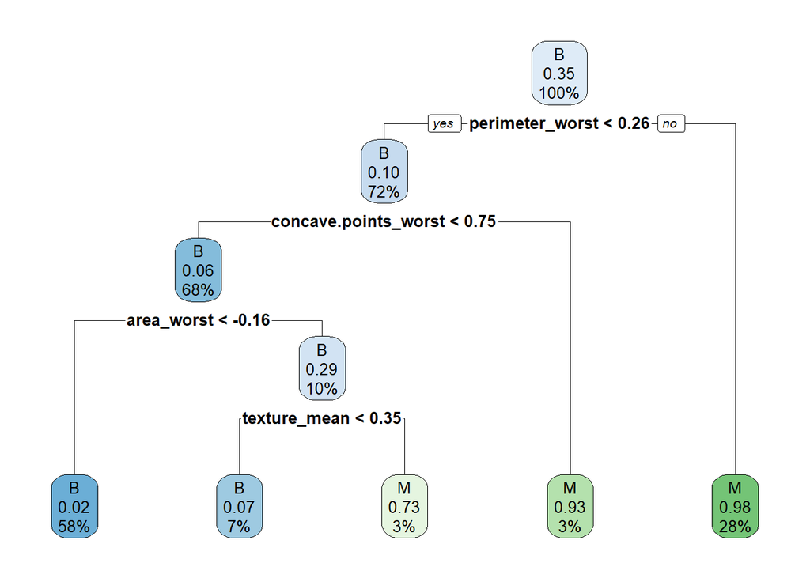

```r
rpart.plot(tree_model)
```

## Interpretation

-Tumors with small perimeter, few concave points, small area, low texture mean → likely benign

-Tumors with larger perimeter and more irregular concave points → likely malignant

-The tree is fairly shallow, indicating a clear separation between B and M in our dataset.

## D) Random Forest

```r
library(randomForest)

# Train Random Forest
rf_model <- randomForest(diagnosis ~ ., data = trainData, ntree = 300)

# Predict on test data
rf_pred <- predict(rf_model, newdata = testData)

# Convert predicted + actual to factors with same levels
rf_pred <- factor(rf_pred, levels = c("B", "M"))
actual_class <- factor(testData$diagnosis, levels = c("B", "M"))

# Confusion matrix
conf_matrix_rf <- table(Predicted = rf_pred, Actual = actual_class)
conf_matrix_rf
```

```
##          Actual
## Predicted  B  M
##         B 58  2
##         M  3 51
```

## Metrics (Accuracy, Sensitivity, Specificity, Precision, F1)

```r
TP <- conf_matrix_rf["M","M"]
TN <- conf_matrix_rf["B","B"]
FP <- conf_matrix_rf["M","B"]
FN <- conf_matrix_rf["B","M"]

accuracy  <- (TP + TN) / sum(conf_matrix_rf)
sensitivity <- TP / (TP + FN)        # Recall for M
specificity <- TN / (TN + FP)        # Recall for B
precision   <- TP / (TP + FP)
f1_score    <- 2 * (precision * sensitivity) / (precision + sensitivity)

list(
  Confusion_Matrix = conf_matrix_rf,
  Accuracy = accuracy,
  Sensitivity = sensitivity,
  Specificity = specificity,
  Precision = precision,
  F1_Score = f1_score
)
```

```
## $Confusion_Matrix
##          Actual
## Predicted  B  M
##         B 58  2
##         M  3 51
##
## $Accuracy
## [1] 0.9561404
##
## $Sensitivity
## [1] 0.9622642
##
## $Specificity
## [1] 0.9508197
##
## $Precision
## [1] 0.9444444
##
## $F1_Score
## [1] 0.953271
```

# STEP 8 — Comparing the results of each model

```r
get_metrics <- function(conf_matrix) {
  TP <- conf_matrix["M","M"]
  TN <- conf_matrix["B","B"]
  FP <- conf_matrix["M","B"]
  FN <- conf_matrix["B","M"]

  accuracy    <- (TP + TN) / sum(conf_matrix)
  sensitivity <- TP / (TP + FN)   # Recall for M
  specificity <- TN / (TN + FP)   # Recall for B
  precision   <- TP / (TP + FP)
  f1_score    <- 2 * (precision * sensitivity) / (precision + sensitivity)

  data.frame(
    Accuracy = accuracy,
    Sensitivity = sensitivity,
    Specificity = specificity,
    Precision = precision,
    F1_Score = f1_score
  )
}
```

The comparison table

```r
model_metrics <- rbind(
  Logistic_Regression = get_metrics(conf_matrix_log),
  KNN_k7              = get_metrics(conf_matrix_knn),
  Decision_Tree       = get_metrics(conf_matrix_tree),
  Random_Forest       = get_metrics(conf_matrix_rf)
)

round(model_metrics, 3)
```

```
##                     Accuracy Sensitivity Specificity Precision F1_Score
## Logistic_Regression    0.965       1.000       0.934     0.930    0.964
## KNN_k7                 0.947       0.906       0.984     0.980    0.941
## Decision_Tree          0.930       0.925       0.934     0.925    0.925
## Random_Forest          0.956       0.962       0.951     0.944    0.953
```

## Conclsion

Logistic Regression achieved the best overall performance among all evaluated models. It provided the highest accuracy and perfect sensitivity, making it the most reliable model for detecting malignant tumors while maintaining interpretability.

# STEP 9 — SAVE the best MODEL

```r
saveRDS(log_model, "logistic_model.rds")
```